# P8105_hw1_dry2115

Dayoung Yu

2018-09-21

## Problem 1

A data frame containing four variables (random sample, logic vector, character vector, and factor vector) was created:

```r
set.seed(2115)

df_uniform = tibble(

    uniform_sample = runif(10, min = 0, max = 5),

    greater_than_2 = (uniform_sample > 2),

    char_vec = c("a","b","c","d","e","f","g","h","i","j"),

    factor_vec = factor(c(0,1,1,0,0,1,0,1,1,1),
                 levels = c(0, 1),
                 label = c("fruit", "vegetable"))
)

df_uniform
```

```
## # A tibble: 10 x 4
##    uniform_sample greater_than_2 char_vec factor_vec
##             <dbl> <lgl>          <chr>    <fct>
##  1          3.60  TRUE           a        fruit
##  2          1.02  FALSE          b        vegetable
##  3          2.72  TRUE           c        vegetable
##  4          0.351 FALSE          d        fruit
##  5          4.03  TRUE           e        fruit
##  6          4.22  TRUE           f        vegetable
##  7          3.97  TRUE           g        fruit
##  8          2.33  TRUE           h        vegetable
##  9          1.53  FALSE          i        vegetable
## 10          4.12  TRUE           j        vegetable
```

The mean of each variable was calculated:

```r
df_means = tibble(

    mean_sample = mean(df_uniform$uniform_sample),
    mean_logic = mean(df_uniform$greater_than_2),
    mean_char = mean(df_uniform$char_vec),
    mean_factor = mean(df_uniform$factor_vec)
)

df_means
```

```
## # A tibble: 1 x 4
##   mean_sample mean_logic mean_char mean_factor
##         <dbl>      <dbl>     <dbl>       <dbl>
## 1        2.79        0.7        NA          NA
```

Means were obtained for the uniform sample variable and logic variable because they consisted of valid numeric values. The logic variable is given values of 0 or 1. The mean function yielded “NA” for the character variable and factor variable because means cannot be calculated for character strings or categorical data.

The logic, character, and factor variables were converted to numeric vectors:

```r
  as.numeric(df_uniform$greater_than_2)
  as.numeric(df_uniform$char_vec)
  as.numeric(df_uniform$factor_vec)
```

Results: The logic vector was converted to corresponding numeric values of 0 and 1 while the factor vector was converted to values of 1 and 2. The character vector could not be converted to numeric.

The character variable was converted to factor to numeric, and the factor variable was converted to charater to numeric:

```r
  char_fact = as.factor(df_uniform$char_vec)
  char_fact_num = as.numeric(char_fact)
  char_fact_num
```

```
##  [1]  1  2  3  4  5  6  7  8  9 10
```

```r
  fact_char = as.character(df_uniform$factor_vec)
  fact_char_num = as.numeric(fact_char)
  fact_char_num
```

```
##  [1] NA NA NA NA NA NA NA NA NA NA
```

The character variables were assigned into factors from 1-10, then converted into corresponding numeric values. The factor variables were converted to corresponding character strings of “fruit” or “vegetable”, but the resulting character values could not be converted to numeric values.

## Problem 2

```r
df_normal = tibble(

    x = rnorm(1000),
    y = rnorm(1000),

    positive_sum = (x + y > 0),
    num_coerce = as.numeric(positive_sum),
    factor_coerce = as.factor(positive_sum)
)

df_normal
```

```
## # A tibble: 1,000 x 5
##          x      y positive_sum num_coerce factor_coerce
##      <dbl>  <dbl> <lgl>             <dbl> <fct>
##  1 -0.145   1.26  TRUE                  1 TRUE
##  2 -1.10   -0.360 FALSE                 0 FALSE
##  3  0.383  -1.67  FALSE                 0 FALSE
##  4 -0.400  -2.23  FALSE                 0 FALSE
##  5 -0.814  -2.05  FALSE                 0 FALSE
##  6 -0.433  -0.484 FALSE                 0 FALSE
##  7  0.0847  0.558 TRUE                  1 TRUE
##  8  0.821  -1.16  FALSE                 0 FALSE
##  9 -1.56    1.67  TRUE                  1 TRUE
## 10  0.0165 -1.31  FALSE                 0 FALSE
## # ... with 990 more rows
```

Descriptive statistics were calculated for the random samples *x* and *y*:

```r
  n_x = length(df_normal$x)
  mean_x = mean(df_normal$x)
  median_x = median(df_normal$x)
  total_true = length(df_normal$positive_sum[df_normal$positive_sum == TRUE])
  prop_true = (total_true / n_x)


  n_y = length(df_normal$y)
  mean_y = mean(df_normal$y)
  median_y = median(df_normal$y)
```

The vectors *x* and *y* are random samples taken from a normal distribution. The random sample *x* has sample size n = 1000, mean = -0.0059783, and median = 0.0437308. The random sample *y* has sample size n = 1000, mean = -0.0121054, and median = -0.0178533. The proportion of cases where *x* + *y* > 0 is 0.49.

# Scatterplots of *x* and *y*:

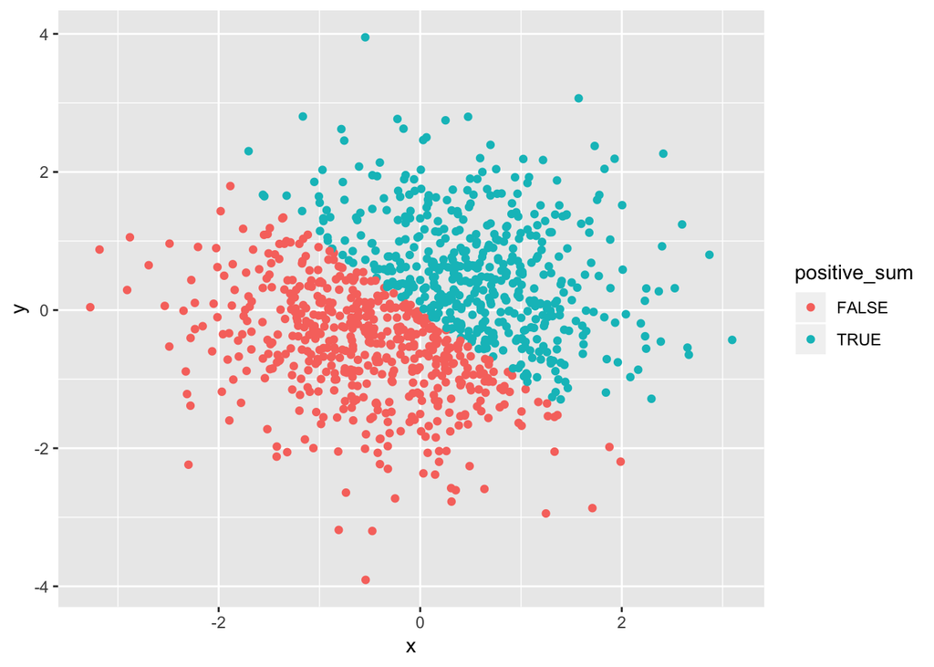

```r
ggplot(df_normal, aes(x = x, y = y, color = positive_sum)) + geom_point()
```

```r
ggsave("scatterplot_logic.pdf", height = 4, width = 6)
```

The scatterplot above is colored by the logical vector, positive_sum. This vector is TRUE for x + y > 0 and FALSE otherwise. Thus, there are only two distinct colors.

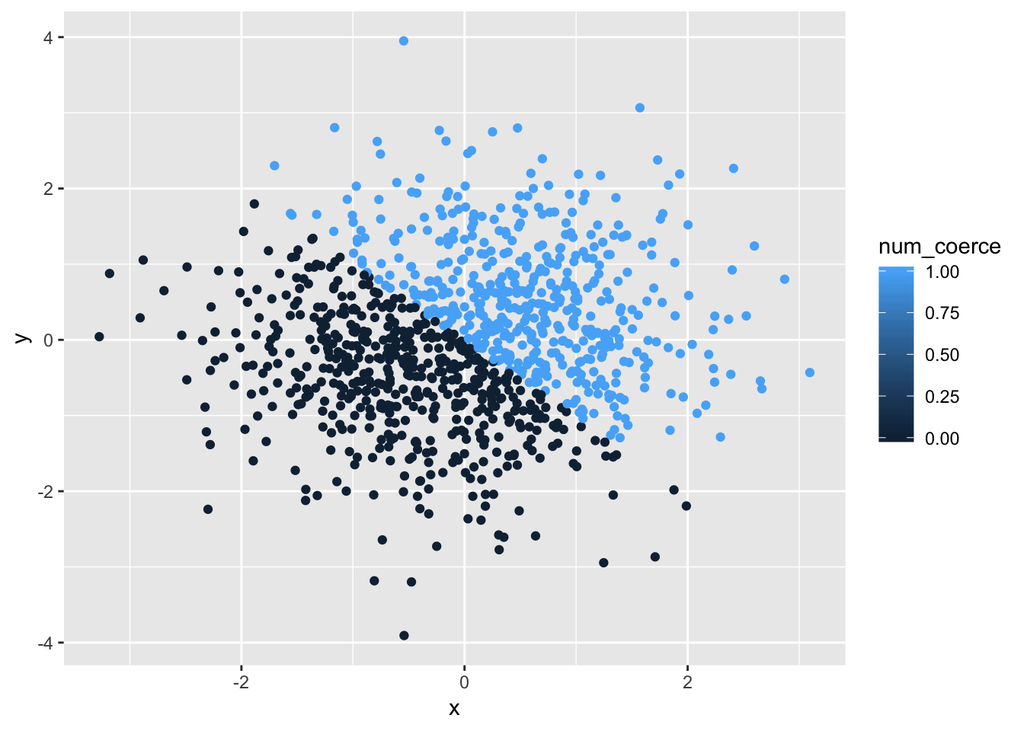

```r
ggplot(df_normal, aes(x = x, y = y, color = num_coerce)) + geom_point()
```

The scatterplot above is colored by the numeric vector, num_coerce. This vector is the logical vector that has been coerced into a numerical vector. Since the vector is numeric, the color scale shows a gradient of colors for values between 0-1. However, since our data only contain integer values 0 and 1, there are only two distinct colors in the plot.

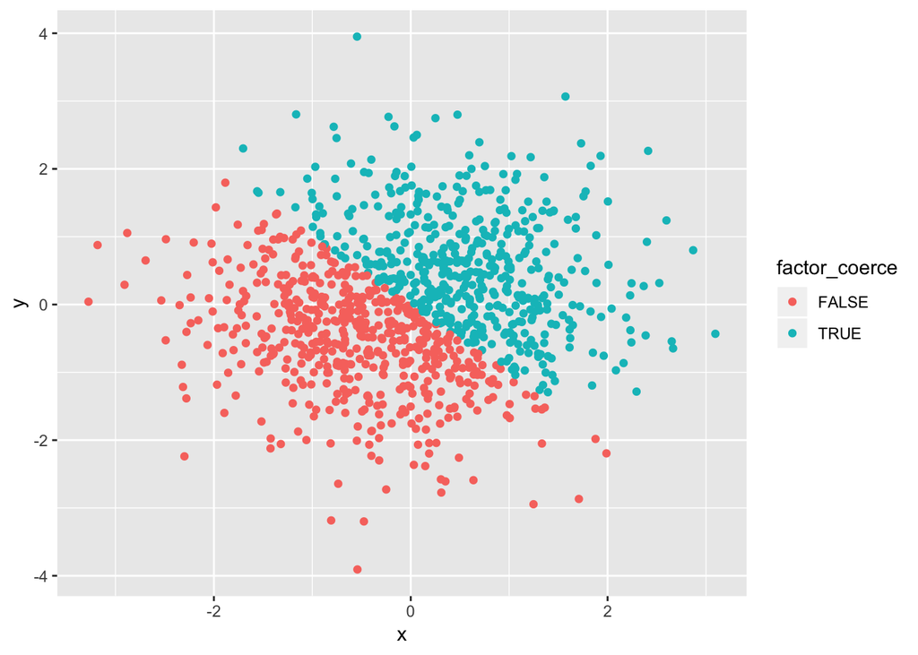

```r
ggplot(df_normal, aes(x = x, y = y, color = factor_coerce)) + geom_point()
```

The scatterplot above is colored by the factor vector that has been coerced from the logical vector. Similar to the logical vector, the factor vector contains two distinct categorical values. Thus, the color scale and plot display only two distinct colors.